# A4: Predicting Dengue

```python
# Import libraries
from sklearn.tree import DecisionTreeClassifier
import pandas as pd
import numpy as np
import matplotlib.pyplot as plt
from sklearn.model_selection import train_test_split
from sklearn import linear_model
from sklearn.metrics import mean_squared_error, r2_score, accuracy_score, confusion_matrix
import statsmodels.api as sm
from sklearn.metrics import explained_variance_score
from sklearn import preprocessing
import matplotlib
from sklearn.ensemble import ExtraTreesClassifier, RandomForestClassifier
from sklearn.model_selection import KFold, GridSearchCV
from sklearn.neighbors import KNeighborsClassifier
from sklearn.naive_bayes import GaussianNB
from sklearn.preprocessing import StandardScaler
from sklearn.feature_selection import SelectFromModel
from sklearn.linear_model import LinearRegression
from sklearn.feature_selection import RFE
import seaborn as sns
from sklearn.linear_model import LogisticRegression
from sklearn import metrics
%matplotlib inline
matplotlib.style.use('ggplot')
```

```python
#read in csvs
test = pd.read_csv("data/dengue_features_test.csv")
train = pd.read_csv("data/dengue_features_train.csv")
labels = pd.read_csv("data/dengue_labels_train.csv")
```

```python
#Just like in assignment 3, I'll be creating a new variable that is the average of all the NVDI's.
train['nvdi_avg'] = train[['ndvi_ne', 'ndvi_nw','ndvi_se','ndvi_sw']].mean(axis=1)
test['nvdi_avg'] = test[['ndvi_ne', 'ndvi_nw','ndvi_se','ndvi_sw']].mean(axis=1)
```

```python
#I'll deal with null values by using the most recent value. This value should be close to what the
#actual value is and allows me to not have to drop the row which would make my dataset smaller and less accurate.
train.fillna(method='ffill', inplace=True)

#dropping city because I do not want to look at each city individually (this would split the data in half)
#and week_start_date because weekofyear serves the same purpose
train_no_lbl = train.drop(['city', 'week_start_date'], axis = 1)
train_no_lbl.fillna(method='ffill', inplace=True)
test_fillna = test
test_fillna.fillna(method='ffill', inplace=True)
```

```python
#Converting data types to float for later analysis (they are now all floats)
train_no_lbl['weekofyear'] = train_no_lbl['weekofyear'].astype(float)
train_no_lbl['year'] = train_no_lbl['year'].astype(float)
```

## Feature Selection

To choose the best covariates to use in our model, I'll be using sklearn's SelectFromModel and the ExtraTreesClassifier, which uses Gini importance to find the feature importance. I chose SelectFromModel using the ExtraTreesClassifier because it's simple but efficient. Since I'll be using the same features across all of my models I'll find them outside of the pipelines to cut down on processing time and to see what variables are chosen and their levels of importance. Feature selection is important to prevent overfitting and for quicker processing.

```python
clf = ExtraTreesClassifier(n_estimators=1000)
clf = clf.fit(train_no_lbl, labels.total_cases)
model = SelectFromModel(clf, prefit=True)
X_new = model.transform(train_no_lbl)
print("The new dataframe shape: ")
print(X_new.shape)
```

```
The new dataframe shape:
(1456, 5)
```

There are **five** important features to include: *year, weekofyear, reanalysis_tdtr_k, station_diur_temp_rng_c,* and *reanalysis_min_air_temp_k*.

The complete ranking of the features can be seen in the visualization below:

```python
feature_importances = pd.DataFrame(clf.feature_importances_,
                                   index = train_no_lbl.columns,
                                    columns=['importance']).sort_values('importance',ascending=False)
feature_importances = feature_importances.reset_index()
```

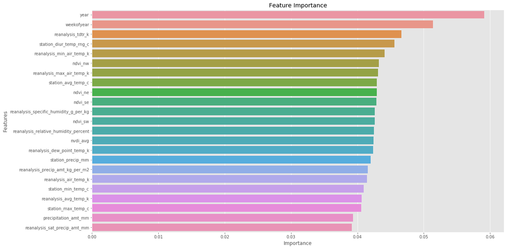

```python
plt.figure(figsize=(18,10))
sns.barplot(x="importance", y="index", data=feature_importances)
plt.ylabel('Features')
plt.xlabel('Importance')
plt.title('Feature Importance')
plt.show()
```

```python
#create arrays for later comparison of model performance
acc = []
MAE = []
MSE = []
mdl = []
```

```python
#create dataframe with selected features
selected = train_no_lbl[['year','weekofyear','reanalysis_tdtr_k','station_diur_temp_rng_c',
                  'reanalysis_min_air_temp_k']]

#create test dataframe with selected features

slct_test = test_fillna[['year','weekofyear','reanalysis_tdtr_k','station_diur_temp_rng_c',
                  'reanalysis_min_air_temp_k']]
```

```python
#create training and testing sets
X_train, X_test, y_train, y_test = train_test_split(selected, labels['total_cases'].astype(float), test_size=0.3)
```

```python
#create folds for future cross validation
folds = KFold(n_splits=5, shuffle=True, random_state=11)
```

## Modeling

### GaussianNB

The Gaussian Naive Bayes classifier uses Bayes’ theorem of there being "naive" independence between features. The accuracy score, mean absolute error, and mean squared error are as follows:

```python
#using StandardScaler to standardize the data
pipe = make_pipeline(StandardScaler(copy=True, with_mean=True, with_std=True), GaussianNB())

#there are no hyperparameters for GaussianNB
param_grid = {
}

grid = GridSearchCV(pipe, param_grid, verbose=0, cv=folds, return_train_score=True)
grid.fit(X_train, y_train)

predictions_1 = grid.predict(X_test)

print('Accuracy score: ' + str(accuracy_score(y_test, predictions_1)))
acc.append(accuracy_score(y_test, predictions_1))

print('MAE: ' + str(metrics.mean_absolute_error(y_test, predictions_1)))
MAE.append(metrics.mean_absolute_error(y_test, predictions_1))

print('MSE: ' + str(metrics.mean_squared_error(y_test, predictions_1)))
MSE.append(metrics.mean_squared_error(y_test, predictions_1))

mdl.append('GaussianNB')
```

```
Accuracy score: 0.07780320366132723
MAE: 21.988558352402745
MSE: 1399.0594965675057
```

```python
results_1 = grid.predict(slct_test)
```

```python
submit_1 = []

for i in range(len(test)):
    submit_dict = {'city': test.city[i], 'year': test.year[i].astype(int),
                'weekofyear': test.weekofyear[i].astype(int), 'total_cases': results_1[i].astype(int)}
    submit_1.append(submit_dict)
submission1 = pd.DataFrame(data = submit_1)
submission1 = submission1[['city','year','weekofyear','total_cases']]
```

```python
#submission1.to_csv("sub_fin_1.csv", encoding='utf-8', index=False)
```

The score for using this model was 30.0529 on the DengAI competition.

### RandomForestClassifier

Random forest uses a collection of decision trees (to simply put it, a desicion tree represents desicion pathways). The accuracy score, mean absolute error, and mean squared error are as follows:

```python
#no normalization/standardization needed for RandomForest
pipe = make_pipeline(RandomForestClassifier())

param_grid = {
    'randomforestclassifier__max_features': ['auto', 'sqrt'],
    'randomforestclassifier__n_estimators': [100, 200, 300, 500]
}

grid = GridSearchCV(pipe, param_grid, verbose=0, cv=folds, return_train_score=True)
grid.fit(X_train, y_train)

predictions_2 = grid.predict(X_test)

print('Accuracy score: ' + str(accuracy_score(y_test, predictions_2)))
#acc.append(accuracy_score(y_test, predictions_2))

print('MAE: ' + str(metrics.mean_absolute_error(y_test, predictions_2)))
#MAE.append(metrics.mean_absolute_error(y_test, predictions_2))

print('MSE: ' + str(metrics.mean_squared_error(y_test, predictions_2)))
#MSE.append(metrics.mean_squared_error(y_test, predictions_2))

#mdl.append('RandomForestClassifier')
```

[output not shown]

```python
print('The parameters selected to use in this model:')
print(grid.best_params_)
```

```
The parameters selected to use in this model:
{'randomforestclassifier__max_features': 'auto', 'randomforestclassifier__n_estimators': 200}
```

```python
results_2 = grid.predict(slct_test)
```

```python
submit_2 = []

for i in range(len(test)):
    submit_dict = {'city': test.city[i], 'year': test.year[i].astype(int),
                'weekofyear': test.weekofyear[i].astype(int), 'total_cases': results_2[i].astype(int)}
    submit_2.append(submit_dict)
submission2 = pd.DataFrame(data = submit_2)
submission2 = submission2[['city','year','weekofyear','total_cases']]
```

```python
#submission2.to_csv("sub_fin_2.csv", encoding='utf-8', index=False)
```

The score for using this model was 31.0240 on the DengAI competition.

### KNeighborsClassifier

The k-Nearest Neighbor classifier finds similar cases to the given data case and then returns the average of the most similar data cases. The accuracy score, mean absolute error, and mean squared error are as follows:

```python
# Scale values to use KNeighbors
pipe = make_pipeline(MinMaxScaler(), KNeighborsClassifier())

# Define a grid to search through
param_grid = {'kneighborsclassifier__n_neighbors':range(1, 100),
              'kneighborsclassifier__weights':["uniform", "distance"]}

# Perform a  grid search of your pipeline
grid = GridSearchCV(pipe, param_grid, verbose=0, cv=folds, return_train_score=True)
grid.fit(X_train, y_train)

predictions_3 = grid.predict(X_test)

print('Accuracy score: ' + str(accuracy_score(y_test, predictions_3)))
acc.append(accuracy_score(y_test, predictions_3))

print('MAE: ' + str(metrics.mean_absolute_error(y_test, predictions_3)))
MAE.append(metrics.mean_absolute_error(y_test, predictions_3))

print('MSE: ' + str(metrics.mean_squared_error(y_test, predictions_3)))
MSE.append(metrics.mean_squared_error(y_test, predictions_3))

mdl.append('KNeighborsClassifier')
```

```
Accuracy score: 0.11899313501144165
MAE: 15.475972540045767
MSE: 1325.9565217391305
```

```python
print('The parameters selected to use in this model:')
```

```
The parameters selected to use in this model:
```

```python
print(grid.best_params_)
```

```
{'kneighborsclassifier__n_neighbors': 85, 'kneighborsclassifier__weights': 'distance'}
```

```python
results_3 = grid.predict(slct_test)
```

```python
submit_3 = []

for i in range(len(test)):
    submit_dict = {'city': test.city[i], 'year': test.year[i].astype(int),
                'weekofyear': test.weekofyear[i].astype(int), 'total_cases': results_3[i].astype(int)}
    submit_3.append(submit_dict)
submission3 = pd.DataFrame(data = submit_3)
submission3 = submission3[['city','year','weekofyear','total_cases']]
```

```python
#submission3.to_csv("sub_fin_3.csv", encoding='utf-8', index=False)
```

### DesicionTreeClassifier

Desicion trees make the best splits, seperating the data for the predictions being made. The accuracy score, mean absolute error, and mean squared error are as follows:

```python
from sklearn.tree import DecisionTreeClassifier
from xgboost import XGBClassifier
import xgboost
```

```python
# Scale values to use KNeighbors
pipe = make_pipeline(DecisionTreeClassifier())

# Define a grid to search through
param_grid = {'decisiontreeclassifier__min_samples_split':[0.2],
              'decisiontreeclassifier__splitter':["best", "random"],
              'decisiontreeclassifier__criterion': ["entropy", "gini"]}

# Perform a  grid search of your pipeline
grid = GridSearchCV(pipe, param_grid, verbose=0, cv=folds, return_train_score=True)
grid.fit(X_train, y_train)

predictions_4 = grid.predict(X_test)

print('Accuracy score: ' + str(accuracy_score(y_test, predictions_4)))
acc.append(accuracy_score(y_test, predictions_4))

print('MAE: ' + str(metrics.mean_absolute_error(y_test, predictions_4)))
MAE.append(metrics.mean_absolute_error(y_test, predictions_4))

print('MSE: ' + str(metrics.mean_squared_error(y_test, predictions_4)))
MSE.append(metrics.mean_squared_error(y_test, predictions_4))

mdl.append('DecisionTreeClassifier')
```

```
Accuracy score: 0.09839816933638444
MAE: 16.553775743707092
MSE: 1398.0
```

```python
print('The parameters selected to use in this model:')
```

```
The parameters selected to use in this model:
```

```python
print(grid.best_params_)
```

```
{'decisiontreeclassifier__criterion': 'gini', 'decisiontreeclassifier__min_samples_split': 0.2, 'decisiontreeclassifier__splitter': 'random'}
```

```python
results_4 = grid.predict(slct_test)
```

```python
submit_4 = []

for i in range(len(test)):
    submit_dict = {'city': test.city[i], 'year': test.year[i].astype(int),
                'weekofyear': test.weekofyear[i].astype(int), 'total_cases': results_4[i].astype(int)}
    submit_4.append(submit_dict)
submission4 = pd.DataFrame(data = submit_4)
submission4 = submission4[['city','year','weekofyear','total_cases']]
```

```python
#submission3.to_csv("sub_fin_3.csv", encoding='utf-8', index=False)
```

### XGBClassifier

Gradient boost classifiers also build desicion trees, but do so one at a time so new trees can correct errors previous trees may have made. The accuracy score, mean absolute error, and mean squared error are as follows:

```python
pipe = make_pipeline(XGBClassifier())

param_grid = {"xgbclassifier__max_depth": [5],
              "xgbclassifier__min_child_weight": [4],
              "xgbclassifier__gamma": [ 0.0],
             }

grid = GridSearchCV(pipe, param_grid, verbose=0, cv=folds, return_train_score=True)
grid.fit(X_train, y_train)

predictions_5 = grid.predict(X_test)

print('Accuracy score: ' + str(accuracy_score(y_test, predictions_5)))
acc.append(accuracy_score(y_test, predictions_5))

print('MAE: ' + str(metrics.mean_absolute_error(y_test, predictions_5)))
MAE.append(metrics.mean_absolute_error(y_test, predictions_5))

print('MSE: ' + str(metrics.mean_squared_error(y_test, predictions_5)))
MSE.append(metrics.mean_squared_error(y_test, predictions_5))

mdl.append('XGBClassifier')
```

```
Accuracy score: 0.12585812356979406
MAE: 15.308924485125859
MSE: 1299.2631578947369
```

```python
results_5 = grid.predict(slct_test)
```

```python
submit_5 = []

for i in range(len(test)):
    submit_dict = {'city': test.city[i], 'year': test.year[i].astype(int),
                'weekofyear': test.weekofyear[i].astype(int), 'total_cases': results_5[i].astype(int)}
    submit_5.append(submit_dict)
submission5 = pd.DataFrame(data = submit_5)
submission5 = submission5[['city','year','weekofyear','total_cases']]
```

```python
#submission5.to_csv("sub_fin_5.csv", encoding='utf-8', index=False)
```

```python
model_array = []
for i in range(len(mdl)):
    model_dict = {'model': mdl[i], 'MSE': MSE[i],
                'MAE': MAE[i], 'Accuracy': acc[i]}
    model_array.append(model_dict)
model_df = pd.DataFrame(data = model_array)
```

```python
mae_df = model_df.drop(['MSE', 'Accuracy'], axis=1)
mse_df = model_df.drop(['MAE', 'Accuracy'], axis=1)
acc_df = model_df.drop(['MAE', 'MSE'], axis=1)
```

## Results

The following are visualizations of the mean absolute error across the models, and the mean squared error across them.

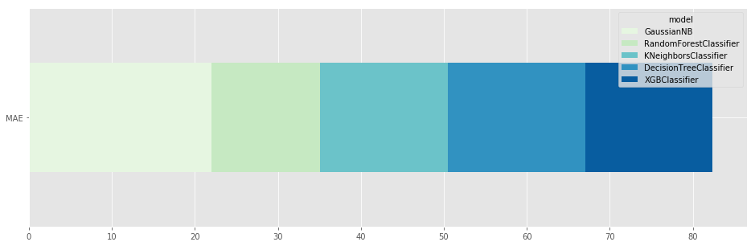

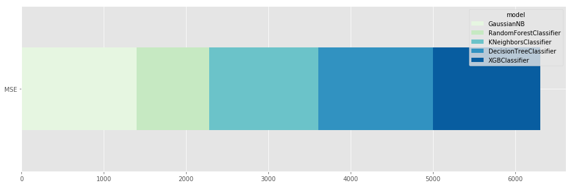

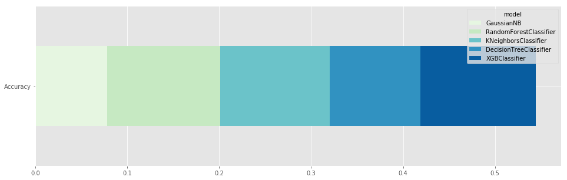

```python
from matplotlib.colors import ListedColormap

mae_df.set_index('model').reindex(mae_df.set_index('model').sum().sort_values().index,
                            axis=1).T.plot(kind='barh', stacked=True,
                                           colormap=ListedColormap(sns.color_palette("GnBu", 10)), figsize=(16,5))

mse_df.set_index('model').reindex(mse_df.set_index('model').sum().sort_values().index,
                            axis=1).T.plot(kind='barh', stacked=True,
                                           colormap=ListedColormap(sns.color_palette("GnBu", 10)), figsize=(16,5))

acc_df.set_index('model').reindex(acc_df.set_index('model').sum().sort_values().index,
                            axis=1).T.plot(kind='barh', stacked=True,
                                           colormap=ListedColormap(sns.color_palette("GnBu", 10)), figsize=(16,5))
```

Here is a table of the exact values:

```python
model_df
```

|  | Accuracy | MAE | MSE | model |
| --- | --- | --- | --- | --- |
| 0 | 0.077803 | 21.988558 | 1399.059497 | GaussianNB |
| 1 | 0.123570 | 13.059497 | 877.132723 | RandomForestClassifier |
| 2 | 0.118993 | 15.475973 | 1325.956522 | KNeighborsClassifier |
| 3 | 0.098398 | 16.553776 | 1398.000000 | DecisionTreeClassifier |
| 4 | 0.125858 | 15.308924 | 1299.263158 | XGBClassifier |

```python
num = list(range(437))
```

### Prediction Accuracy Across the Models

The line graphs in this section show the accuracy of the predictions across the models.

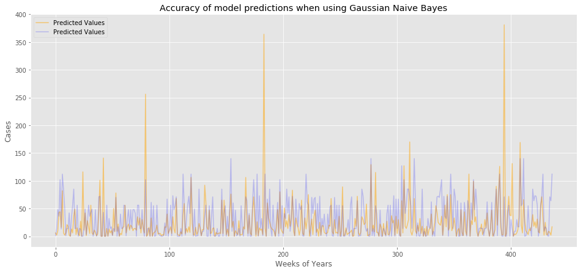

```python
plt.figure(figsize=(16,7))
plt.plot(num, y_test, alpha = .5, color = 'orange', label = 'Predicted Values')
plt.plot(num, predictions_1, alpha = .2, color = 'blue', label = 'Predicted Values')
plt.title('Accuracy of model predictions when using Gaussian Naive Bayes')
plt.legend(loc='upper left')
plt.xlabel('Weeks of Years')
plt.ylabel('Cases')
```

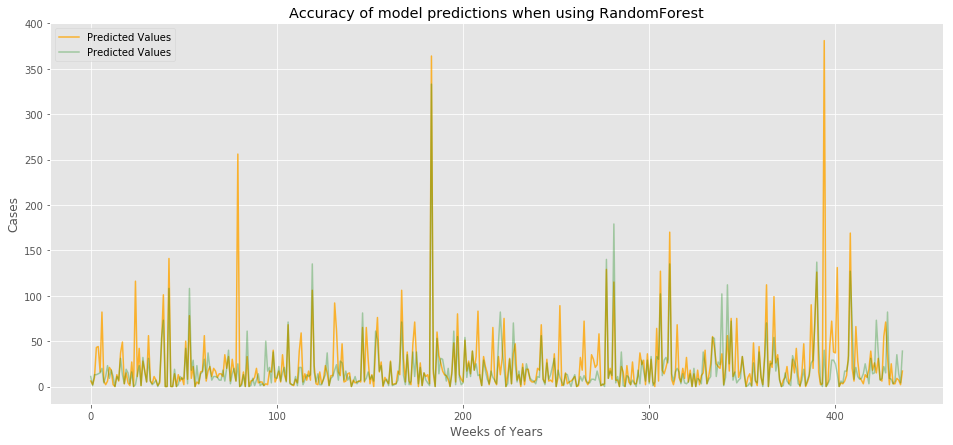

```python
plt.figure(figsize=(16,7))
plt.plot(num, y_test, alpha = .8, color = 'orange',  label = 'Predicted Values')
plt.plot(num, predictions_2, alpha = .3, color='green', label = 'Predicted Values')
plt.title('Accuracy of model predictions when using RandomForest')
plt.legend(loc='upper left')
plt.xlabel('Weeks of Years')
plt.ylabel('Cases')
```

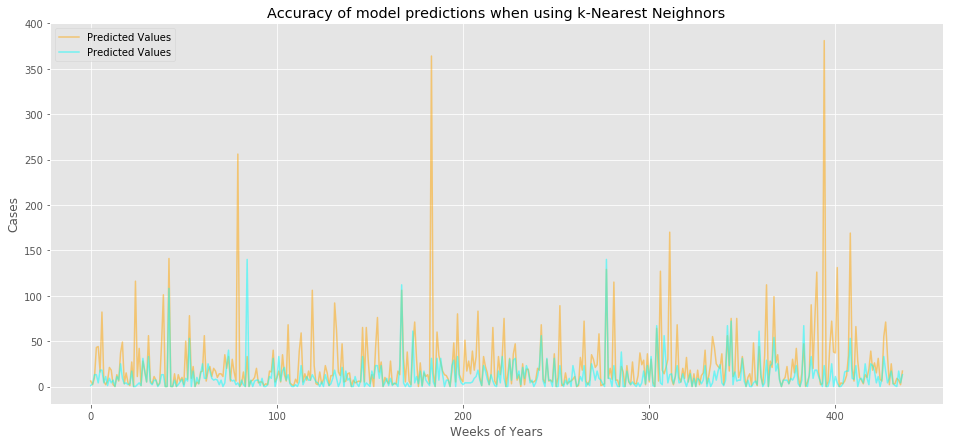

```python
plt.figure(figsize=(16,7))
plt.plot(num, y_test, alpha = .5, color = 'orange', label = 'Predicted Values')
plt.plot(num, predictions_3, alpha = .5,  color='cyan', label = 'Predicted Values')
plt.title('Accuracy of model predictions when using k-Nearest Neighnors')
plt.legend(loc='upper left')
plt.xlabel('Weeks of Years')
plt.ylabel('Cases')
```

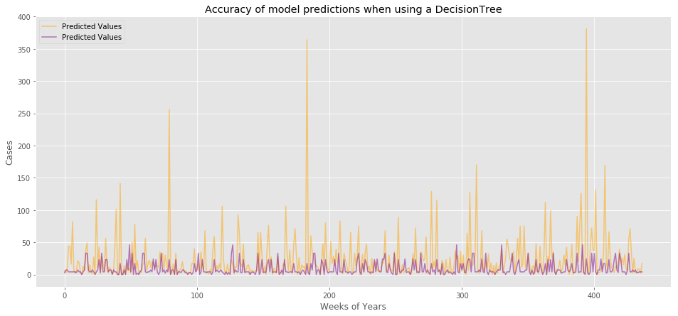

```python
plt.figure(figsize=(16,7))
plt.plot(num, y_test, alpha = .5, color = 'orange', label = 'Predicted Values')
plt.plot(num, predictions_4, alpha = .5, color='purple', label = 'Predicted Values')
plt.title('Accuracy of model predictions when using a DecisionTree')
plt.legend(loc='upper left')
plt.xlabel('Weeks of Years')
plt.ylabel('Cases')
```

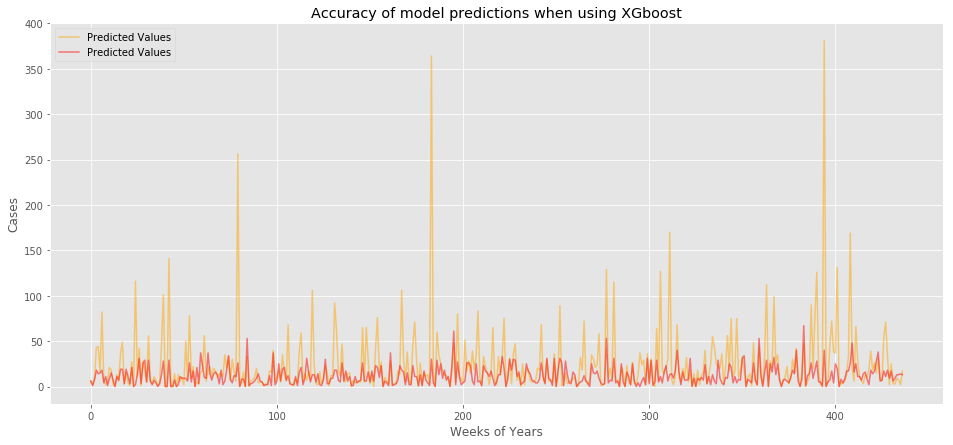

```python
plt.figure(figsize=(16,7))
plt.plot(num, y_test, alpha = .5, color = 'orange', label = 'Predicted Values')
plt.plot(num, predictions_5, alpha = .5, color = 'red', label = 'Predicted Values')
plt.title('Accuracy of model predictions when using XGboost')
plt.legend(loc='upper left')
plt.xlabel('Weeks of Years')
plt.ylabel('Cases')
```

For the DengAI competition, I haven't been able to check the scores of all my models because of the submission limitation, but so far the GaussianNB model is in the lead.